# Data Crafters_EDA

### 5.5 Comparing Sale of Diesel and Unleaded based on Fuel Station Features

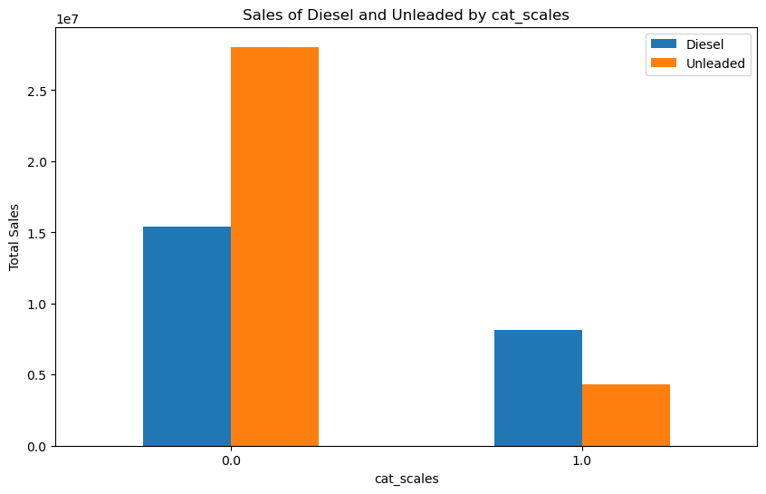

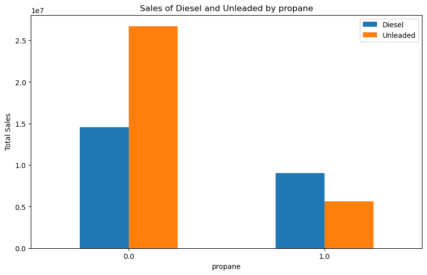

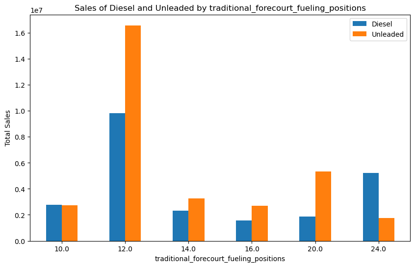

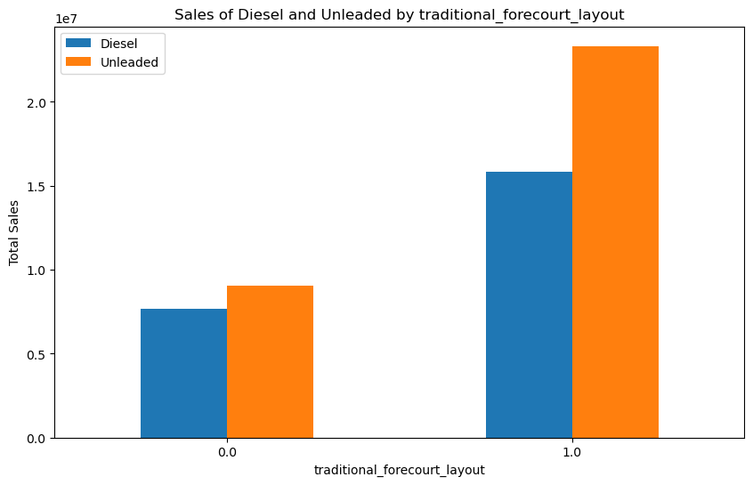

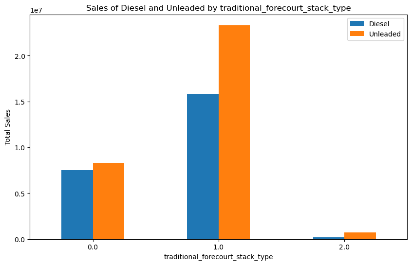

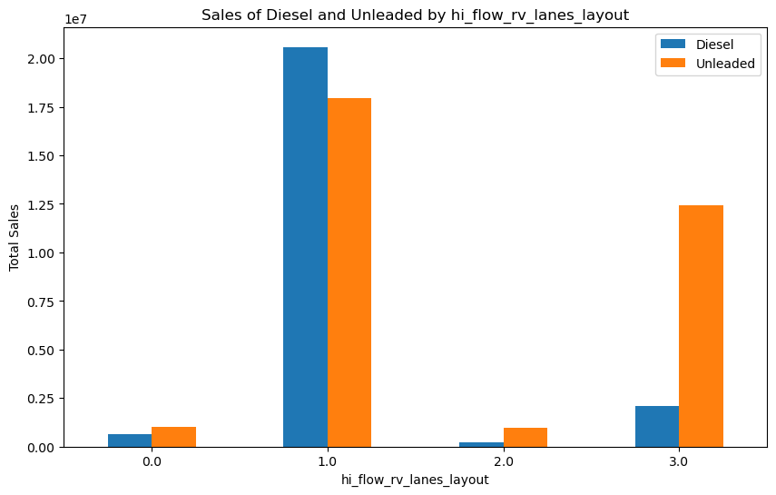

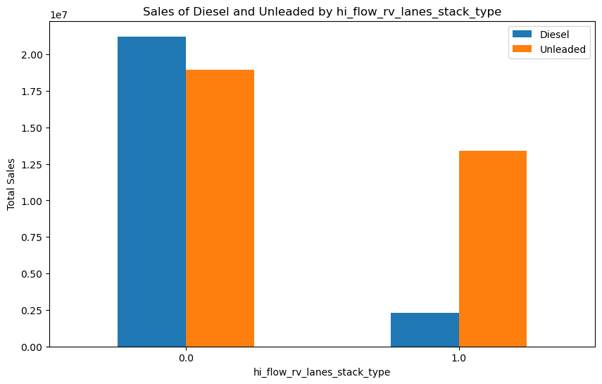

```python
columns_to_visualize = ['cat_scales', 'propane', 'traditional_forecourt_fueling_positions',
                        'traditional_forecourt_layout', 'traditional_forecourt_stack_type',
                        'hi_flow_rv_lanes_layout', 'hi_flow_rv_lanes_stack_type']

for column in columns_to_visualize:

    sales_by_column = df_merged.groupby(column)[['diesel', 'unleaded']].sum()
    sales_by_column.plot(kind='bar', figsize=(10, 6))
    plt.title(f'Sales of Diesel and Unleaded by {column}')
    plt.xlabel(column)
    plt.ylabel('Total Sales')
    plt.xticks(rotation=0)
    plt.legend(['Diesel', 'Unleaded'])
    plt.show()
```

#### 3. Maximum maverik store has 12 fueling position where it gets the maximum revenue.

#### 4. Unleaded gets more revenue for both stack and inline forecourt layout.

#### 5. Unleaded sale is more if the stack type is large or xl compared to diesel.

#### 6. Diesel sale is more for combo style of hi-flo rv lanes layout and hi-flo rv lane stack type.

### 5.6 Comparing Sale of Diesel based on Fuel Station Features

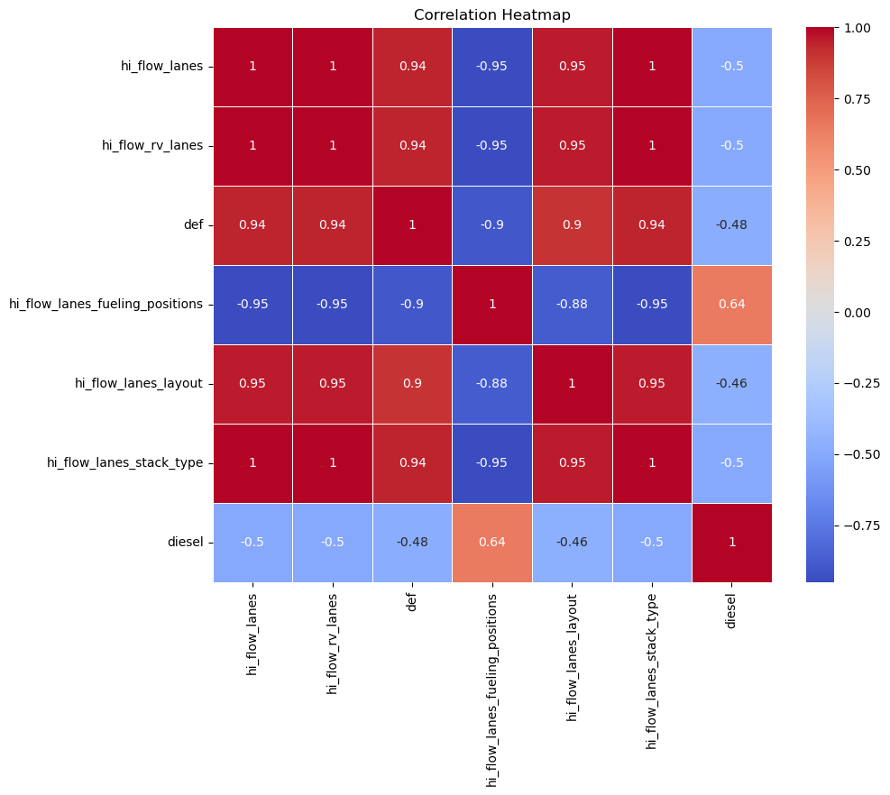

```python
numerical_columns = ['hi_flow_lanes', 'hi_flow_rv_lanes', 'def',
                     'hi_flow_lanes_fueling_positions', 'hi_flow_lanes_layout',
                     'hi_flow_lanes_stack_type', 'diesel']

subset_df = df_merged[numerical_columns]

correlation_matrix = subset_df.corr()

plt.figure(figsize=(10, 8))
sns.heatmap(correlation_matrix, annot=True, cmap='coolwarm', linewidths=0.5)
plt.title('Correlation Heatmap')
plt.show()
```

##### We observe that sale of diesel increases if there is an increase in the number of hi flow lanes fueling positions.

### 5.7 Comparing Sale of Unleaded based on Fuel Station Features

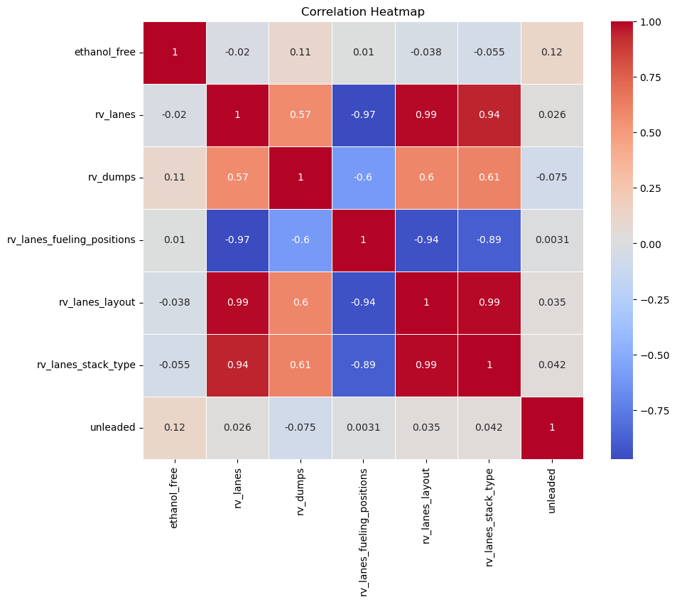

```python
numerical_columns =  [ 'ethanol_free', 'rv_lanes', 'rv_dumps',
                        'rv_lanes_fueling_positions', 'rv_lanes_layout',
                        'rv_lanes_stack_type', 'unleaded']

subset_df = df_merged[numerical_columns]


correlation_matrix = subset_df.corr()


plt.figure(figsize=(10, 8))
sns.heatmap(correlation_matrix, annot=True, cmap='coolwarm', linewidths=0.5)
plt.title('Correlation Heatmap')
plt.show()
```

## IV. Results

### 16.Identified specific food sales categories like "freal," "bonfire_grill," "pizza," and "cinnabon" as key drivers.

### These insights provide valuable starting points for developing models and strategies to forecast sales and inform decision-making for Maverik.

## V. Contributions

1. Krishna Chaitanya: Business Problem Statement, Correlation Matrix, Seasonality, Analysis of unleaded and diesel sales, Results
2. Anukriti: Business Problem Statement, Data Description,Seasonality, Correlation Matrix,Analysis of unleaded and diesel sales, Results
3. Shivi Shrivastav: Business Problem Statement,Introduction, Data Description, Table of Contents, Seasonality, Analysis of in-store and food sales salesResults
4. Litzy Carbajal: Business Problem Statement, Introduction ,Seasonality, Analysis of in-store and food sales, Results.